# WITM analysis

2024-09-12

## Where is the Money for Feminist Organizing? Survey for feminist, women’s rights and gender justice movements, groups and organizations

The Where is the Money for Feminist Organizing survey (in short, Where is the Money or WITM) was developed by AWID – a global, feminist, membership, movement-support organization – in a consultative process with our members and movement partners.

The survey aims to:

*Shine light on the financial status of feminist, women’s rights and gender justice organizing

*Make the complex resourcing realities of diverse feminist movements visible

*Reflect on the funding ecosystem and trends impacting feminist and gender justice movements regionally and globally

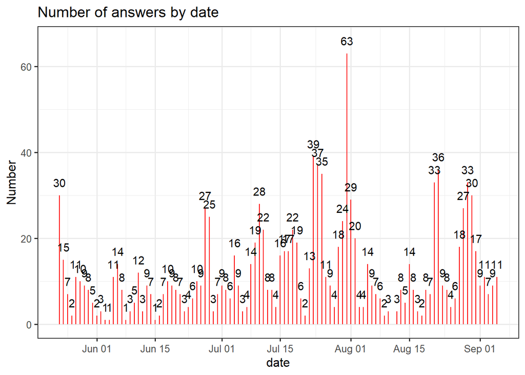

**-.-.-.-.-.-.-.-.-.-.-.-.-.-.-.-.-.-.-.-.-.-.-.-.-.-.-.-.-.-**

**Consent**

Q1. I consent to take the WITM survey on behalf of my group, organization or movement.

| Consent | Count | Percentage |
| --- | --- | --- |
| yes | 1249 | 100 |

**-.-.-.-.-.-.-.-.-.-.-.-.-.-.-.-.-.-.-.-.-.-.-.-.-.-.-.-.-.-**

## Section 1: Group Information

**Organization focus**

Q2. Which of the following statements best describes your group, organization and/or movement?

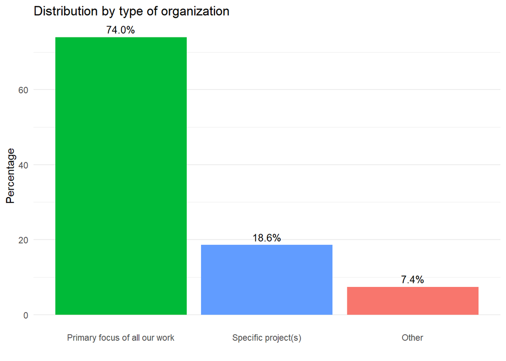

**Organization names:**

Q3. The name of your group, organization and/or movement

```
## [1] "The number of organizations that did not answer their name is: 85"
```

**Type of organization**

Q4. Which of the following forms of organizing best describes your group, organization and/or movement?

*This is a multiple-choice question so the sum of the % does NOT add up to 100.*

| Organization type | Count | Percentage |
| --- | --- | --- |
| Women’s rights | 913 | 73.1 |
| Ending gender based violence | 847 | 67.8 |
| Human rights | 719 | 57.6 |
| Sexual and reproductive health & rights (SRHR) and bodily autonomy | 668 | 53.5 |
| Young feminists | 457 | 36.6 |
| Economic justice, rights and alternatives | 409 | 32.7 |
| Climate and environmental justice | 393 | 31.5 |
| Human rights defenders at risk | 376 | 30.1 |
| Girls’ movements | 326 | 26.1 |
| Countering anti-gender and anti-rights | 311 | 24.9 |
| Lesbian, Bisexual and queer rights | 310 | 24.8 |
| Disability rights and justice | 288 | 23.1 |
| Rights for people living with HIV+ | 287 | 23.0 |
| Sex workers rights | 257 | 20.6 |
| Trans and non-binary rights | 253 | 20.3 |
| Holistic safety, protection and collective care | 251 | 20.1 |
| Indigenous rights | 250 | 20.0 |
| Displaced, migrant and refugee rights | 244 | 19.5 |
| Crisis response | 224 | 17.9 |
| Labour rights | 217 | 17.4 |
| Black rights/ Black feminist rights | 206 | 16.5 |
| Digital rights | 192 | 15.4 |
| Freedom of information and media | 159 | 12.7 |
| Racial justice | 154 | 12.3 |
| Pleasure and bodily care | 153 | 12.2 |
| Harm reduction | 146 | 11.7 |
| Intersex rights | 141 | 11.3 |
| Religious and ethnic minority rights | 125 | 10.0 |
| Anti-militarization and peace | 113 | 9.0 |
| Other | 64 | 5.1 |
| Resisting the war on drugs | 55 | 4.4 |
| Anti-caste | 52 | 4.2 |

**Type of organization - grouped (q4_grouped)**

This variable is constructed by recognizing the organizations that work on one of AWID’s focus topics and those that do not, are placed as “other subjects (not focus)”.

- Lesbian, bisexual and queer rights
- Sex workers rights
- Trans and non-binary-rights
- Anti-caste
- Climate and environmental justice
- Countering anti-gender and anti-rights
- Anti-militarization and peace
- Holistic safety, protection and collective care

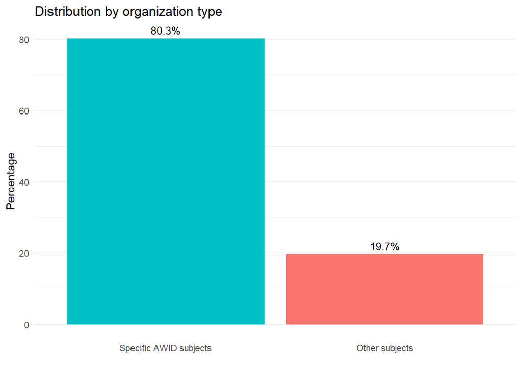

**Spotlight themes/groups**

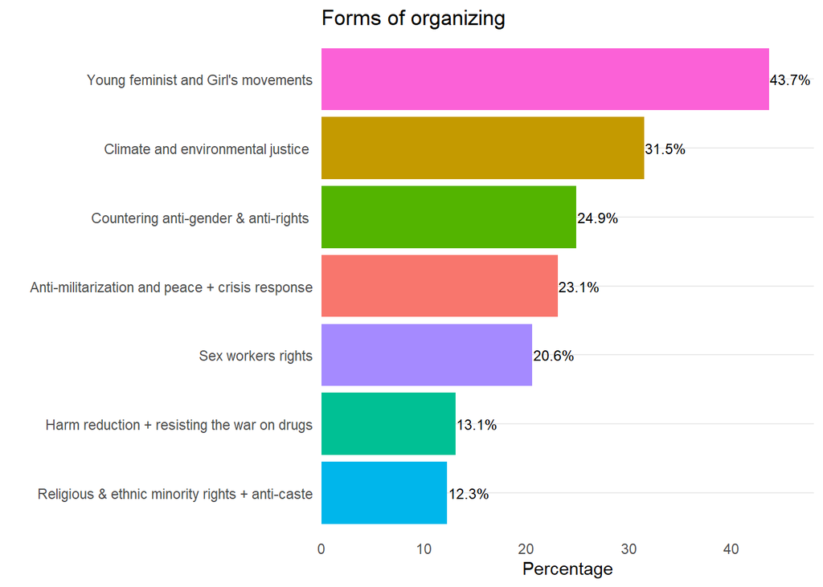

**Registration**

Q5. Is your group, organization and/or movement registered?

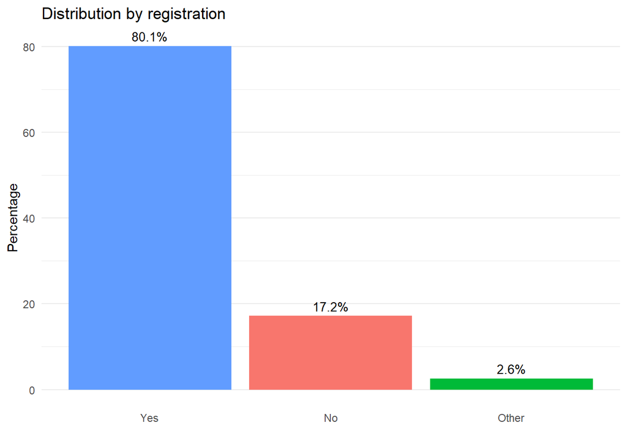

**Scope**

Q6. What is the geographical scope of your work?

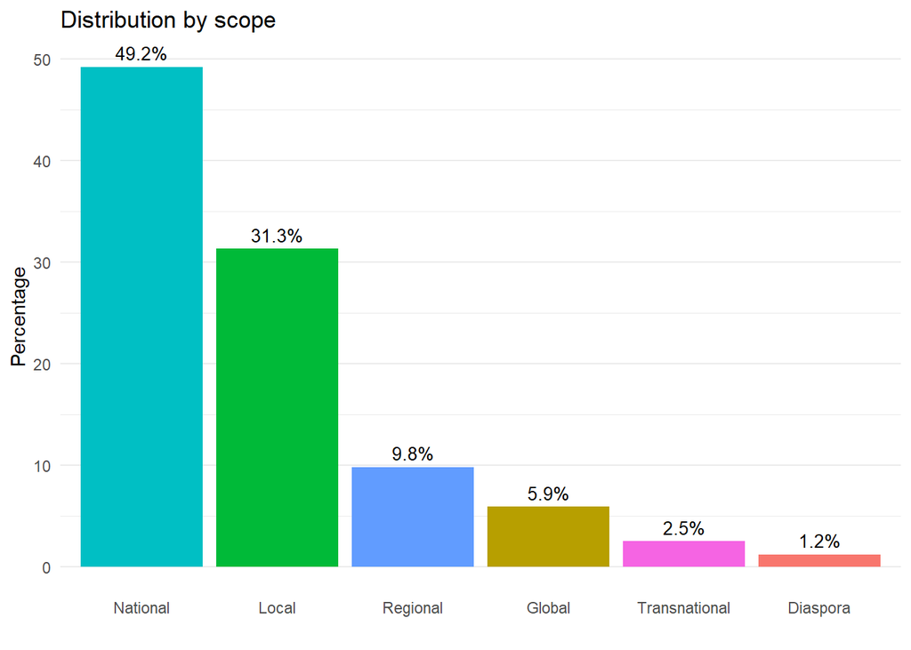

**Region**

Q7. Indicate in which region(s) your group, organization and/or movement works

| Region | Count | Percentage |
| --- | --- | --- |
| South America | 254 | 20.3 |
| East Africa | 203 | 16.3 |
| South Asia | 179 | 14.3 |
| Central America & Mexico | 175 | 14.0 |
| West Africa | 166 | 13.3 |
| Central Africa | 123 | 9.8 |
| Southeast Asia | 95 | 7.6 |
| Southern Africa | 94 | 7.5 |
| Caribbean | 83 | 6.6 |
| Eastern Europe, Southeast Europe and Central Europe | 83 | 6.6 |
| South West Asia/Middle East | 77 | 6.2 |
| Western Europe | 71 | 5.7 |
| North Africa | 68 | 5.4 |
| North America | 64 | 5.1 |
| The Pacific | 47 | 3.8 |
| Central Asia & Caucasus | 44 | 3.5 |
| East Asia | 41 | 3.3 |

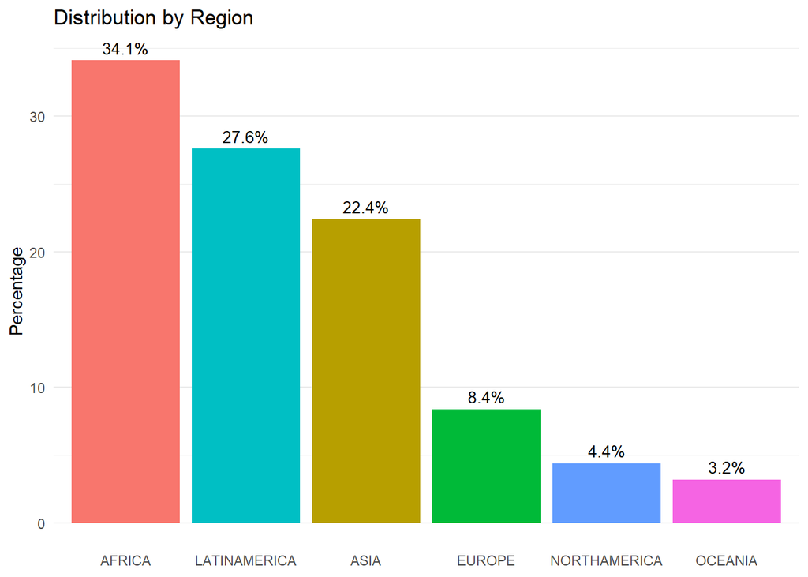

**Year of formation**

Q9. What year was your group, organization and/ or movement formed?

q9_year_formation_agrup

total

Percentage

1. 2021-2023

192

15.4

2. From 2015 to 2020

410

32.8

3. From 2010 to 2014

227

18.2

4. From 2000 to 2009

251

20.1

5. Before 2000

169

13.5

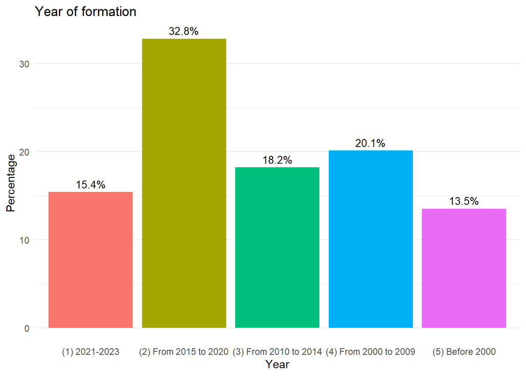

**-.-.-.-.-.-.-.-.-.-.-.-.-.-.-.-.-.-.-.-.-.-.-.-.-.-.-.-.-.-**

## Section 2: Financial Status

*This section asks about the financial status of your group, organization and/or movement over the last three years, from 2021 to 2023. This includes questions about your annual budget, the sources and type of external funding you receive and the resources you mobilize autonomously. To account for the impact that COVID-19 and other crises may have had on your budgets, we have included one question that dates back to 2019. This section is very important to this survey, and we request that you are as accurate in your responses as possible.*

**Annual budget**

Q10. What was the annual budget for your group, organization and/or movement in each of the following years in $USD?

Annual_budget

Percentage_2021

Percentage_2022

Percentage_2023

1. Zero budget

15.4

13.0

11.4

2. <5000

19.0

17.2

16.4

3. 5001-10000

11.8

12.2

10.9

4. 10001-30000

13.4

15.0

15.7

5. 30001 -50000

8.7

8.0

9.0

6. 50001 - 100000

9.5

11.1

11.5

7. 100,001 – 500,001 USD

14.4

15.0

15.8

8. 500,001 – $1,000,000 USD

4.5

5.1

5.6

1. 1,000,001 + USD

3.3

3.5

3.6

**COVID-19 impact**

Q11. In 2020 (during COVID-19 pandemic), how was your budget affected?

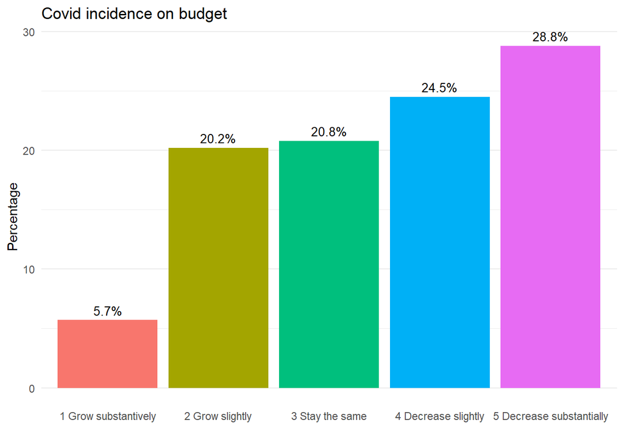

**-.-.-.-.-.-.-.-.-.-.-.-.-.-.-.-.-.-.-.-.-.-.-.-.-.-.-.-.-.-**

### Sub-section 2.1: External funding

*External funding includes grants and other forms of funding from philanthropic foundations, governments, bilateral, multilateral or corporate funders and individual donors. It excludes resources that groups, organizations and/or movements generate autonomously such as, for example, membership fees, the voluntary contributions of staff, members and/or supporters, community fundraisers, venue hires or sale of services.*

Q13. Between 2021 and 2023, did your group, organization and/or movement receive any external funding?

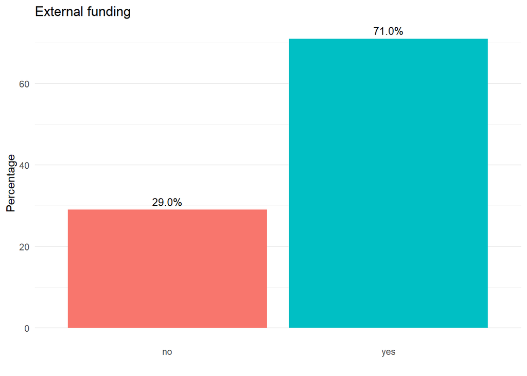

**External funding by year**

Q14. Please indicate the percentage of external funding in your total annual budget for each year:

| Percentage of External Funding in Total Annual Budget | 2021 | 2022 | 2023 |
| --- | --- | --- | --- |
| 1 Lower than 30% | 16.9 | 15.0 | 11.7 |
| 2 Between 30% and 40% | 11.6 | 11.0 | 11.6 |
| 3 Between 50% and 60% | 11.6 | 11.0 | 11.0 |
| 4 Between 70% and 80% | 15.7 | 18.8 | 19.8 |
| 5 Higher than 80% | 44.2 | 44.2 | 45.9 |

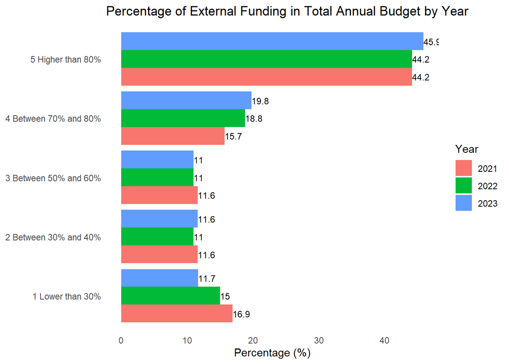

**SOURCES OF EXTERNAL FUNDING**

**Bilateral Funders**: governments of countries in the Global North and South that provide grants or any other form of financial support to civil society organizations in the world’s majority countries of the Global South (e.g. The Dutch Ministry of Foreign Affairs or The Mexican Agency for International Development Cooperation). For the purpose of this survey, bilateral funding also includes embassies and other government-run agencies (e.g. the British Council or Alliance Francaise).

**Multilateral Funders**: grant-giving arms of international intergovernmental organizations (e.g. the United Nations Trust Fund to End Violence against Women or the Global Fund to Fight HIV, Tuberculosis and Malaria).

**Philanthropic Foundations**: umbrella term for foundations of all sizes, both private (i.e. usually set up by wealthy individuals and/or families, e.g. the Ford Foundation) and public (i.e. foundations that mobilize funding from multiple sources, including governments and the general public, e.g. Foundation for a Just Society). For the purpose of this survey, we distinguish between two specific types of Philanthropic Foundations:

**Women’s and Feminist Funds**: public foundations operating globally, regionally, sub-regionally and nationally that fund feminist, trans, intersex and non-binary organizing as their core mission (e.g. Mama Cash, Black Feminist Fund or Women’s Fund Asia); and Corporate Foundations: private foundations, most often the social responsibility arms of the private sector, usually of multinational corporations (e.g. the Ikea Foundation).

**International Non-Governmental Organizations (INGOs)**: large organizations running their own programmes in multiple countries, which often also provide financial support to local civil society partners (e.g. Save the Children, Oxfam, CARE International).

**Individual donors**: wealthy private individuals, who support the work of a specific group, organization and/or movement through financial or in-kind gifts. For example, McKenzie Scott is the individual donor who has given the highest amount of her wealth to feminist movements to date.

**National and local governments or bodies**: many feminist and women’s rights groups also receive grants and other forms of financial support from different arms of their countries’ governments, including local or municipal authorities, and other sources.

Q15. Considering these definitions, what were your group, organization, and/or movement’s key sources of external funding between 2021 and 2023?

| Source | Percentage |
| --- | --- |
| Multirateral | 17.7 |
| Bilateral | 19.4 |
| Philanthropic | 31.9 |
| Feminist | 55.4 |
| Private | 10.7 |
| INGOS | 35.6 |
| Individual | 23.4 |
| Government | 15.2 |
| Other | 5.4 |

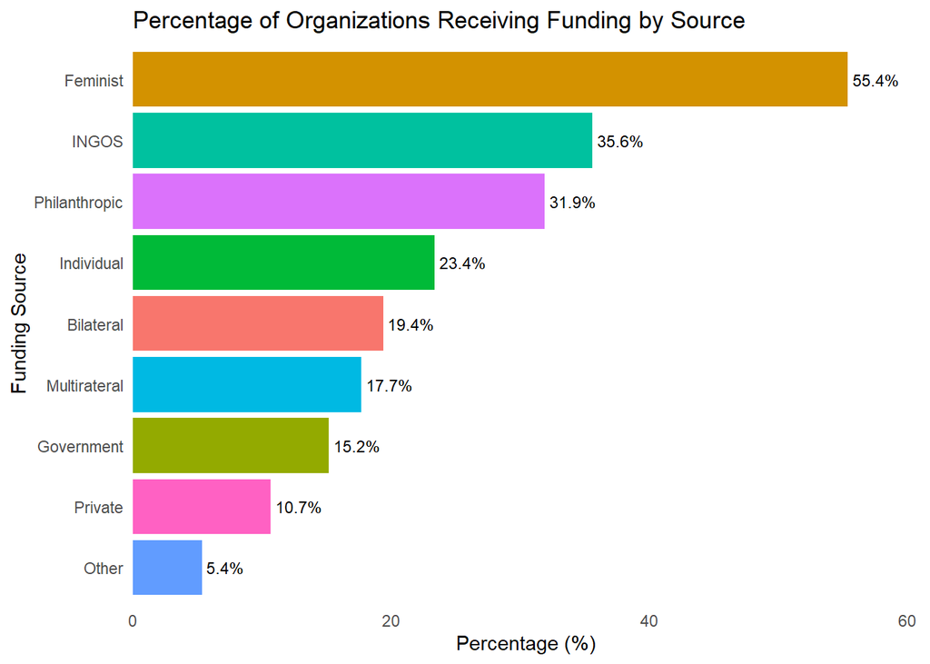

**External funding source by year**

Q16. Please indicate the percentage of each source of external funding for your budget in 2021, 2022 and 2023

*Funding from 2023*

| Range | % Bilateral | % Feminist | % Goverment | % Individual | % INGOS | % Multirateral | % Philanthropic | % Private | % Other |
| --- | --- | --- | --- | --- | --- | --- | --- | --- | --- |
| 0 | 17.4 | 13.0 | 16.3 | 16.3 | 21.2 | 16.6 | 12.7 | 16.8 | 29.2 |
| 10 | 14.0 | 15.7 | 29.6 | 41.3 | 14.6 | 19.1 | 14.1 | 28.4 | 20.8 |
| 20 | 14.5 | 11.2 | 17.8 | 16.3 | 15.2 | 12.7 | 15.2 | 21.1 | 16.7 |
| 30 | 11.6 | 11.4 | 6.7 | 9.1 | 11.4 | 14.6 | 11.3 | 14.7 | 10.4 |
| 40 | 6.4 | 6.9 | 5.9 | 3.8 | 9.5 | 8.3 | 11.7 | 10.5 | 2.1 |
| 50 | 5.8 | 9.4 | 5.9 | 3.4 | 6.6 | 5.1 | 7.4 | 3.2 | 2.1 |
| 60 | 11.0 | 4.9 | 2.2 | 2.4 | 5.4 | 5.7 | 5.3 | NA | 2.1 |
| 70 | 6.4 | 5.5 | 3.0 | 1.9 | 3.2 | 5.7 | 5.7 | 1.1 | NA |
| 80 | 4.7 | 6.1 | 4.4 | 1.4 | 5.1 | 5.1 | 6.4 | 3.2 | 6.2 |
| 90 | 5.2 | 6.7 | 3.7 | 2.9 | 3.8 | 2.5 | 3.2 | 1.1 | 8.3 |
| 100 | 2.9 | 9.2 | 4.4 | 1.0 | 4.1 | 4.5 | 7.1 | NA | 2.1 |

*Funding from 2022*

| Range | % Bilateral | % Feminist | % Goverment | % Individual | % INGOS | % Multirateral | % Philanthropic | % Private | % Other |
| --- | --- | --- | --- | --- | --- | --- | --- | --- | --- |
| 0 | 19.2 | 23.8 | 26.7 | 25.5 | 24.7 | 24.2 | 20.8 | 23.2 | 37.5 |
| 10 | 14.5 | 13.2 | 22.2 | 36.1 | 11.7 | 19.1 | 12.0 | 35.8 | 16.7 |
| 20 | 15.7 | 11.8 | 14.1 | 13.0 | 17.7 | 11.5 | 12.7 | 10.5 | 14.6 |
| 30 | 12.2 | 8.6 | 7.4 | 6.2 | 12.0 | 13.4 | 10.6 | 13.7 | 4.2 |
| 40 | 3.5 | 5.3 | 5.2 | 2.9 | 6.3 | 6.4 | 10.2 | 6.3 | NA |
| 50 | 6.4 | 9.8 | 5.9 | 2.9 | 7.9 | 8.9 | 7.1 | 1.1 | 4.2 |
| 60 | 5.2 | 4.5 | 1.5 | 1.9 | 3.5 | 3.2 | 3.2 | 2.1 | NA |
| 70 | 7.0 | 4.1 | 5.9 | 1.9 | 2.8 | 4.5 | 7.1 | 1.1 | NA |
| 80 | 7.0 | 3.9 | 3.0 | 2.4 | 6.0 | 2.5 | 5.3 | 4.2 | 8.3 |
| 90 | 4.1 | 5.9 | 3.0 | 2.9 | 2.5 | 3.2 | 3.2 | 2.1 | 4.2 |
| 100 | 4.1 | 7.9 | 4.4 | 1.9 | 4.4 | 3.2 | 6.7 | NA | 8.3 |
| NA | 1.2 | 1.2 | 0.7 | 2.4 | 0.3 | NA | 1.1 | NA | 2.1 |

*Funding from 2021*

| Range | % Bilateral | % Feminist | % Goverment | % Individual | % INGOS | % Multirateral | % Philanthropic | % Private | % Other |
| --- | --- | --- | --- | --- | --- | --- | --- | --- | --- |
| 0 | 33.1 | 30.5 | 32.6 | 26.4 | 29.4 | 28.7 | 22.6 | 22.1 | 41.7 |
| 10 | 9.3 | 10.2 | 25.2 | 33.7 | 13.0 | 17.2 | 11.3 | 32.6 | 6.2 |
| 20 | 14.0 | 11.2 | 11.9 | 13.5 | 13.0 | 11.5 | 14.1 | 16.8 | 16.7 |
| 30 | 6.4 | 8.8 | 5.9 | 4.3 | 8.5 | 8.3 | 6.7 | 11.6 | 4.2 |
| 40 | 6.4 | 5.5 | 3.0 | 1.4 | 7.0 | 5.7 | 7.8 | 7.4 | 2.1 |
| 50 | 4.7 | 5.5 | 2.2 | 2.4 | 7.0 | 7.6 | 8.5 | 3.2 | 2.1 |
| 60 | 4.1 | 3.3 | 1.5 | 1.9 | 2.5 | 4.5 | 2.8 | 1.1 | NA |
| 70 | 7.0 | 2.2 | 5.2 | 2.4 | 3.8 | 4.5 | 4.2 | NA | 2.1 |
| 80 | 5.2 | 4.9 | 2.2 | 2.9 | 2.8 | 3.8 | 6.7 | 1.1 | 4.2 |
| 90 | 3.5 | 6.5 | 3.0 | 2.4 | 3.5 | 3.2 | 3.5 | 2.1 | 2.1 |
| 100 | 4.1 | 7.1 | 3.7 | 2.9 | 5.7 | 3.2 | 7.8 | 1.1 | 8.3 |
| NA | 2.3 | 4.3 | 3.7 | 5.8 | 3.8 | 1.9 | 3.9 | 1.1 | 10.4 |

**New funders**

Q18. Between 2021 and 2023, which new funders, if any, did you receive funding from?

*Reception of new funding between 2021 and 2023*

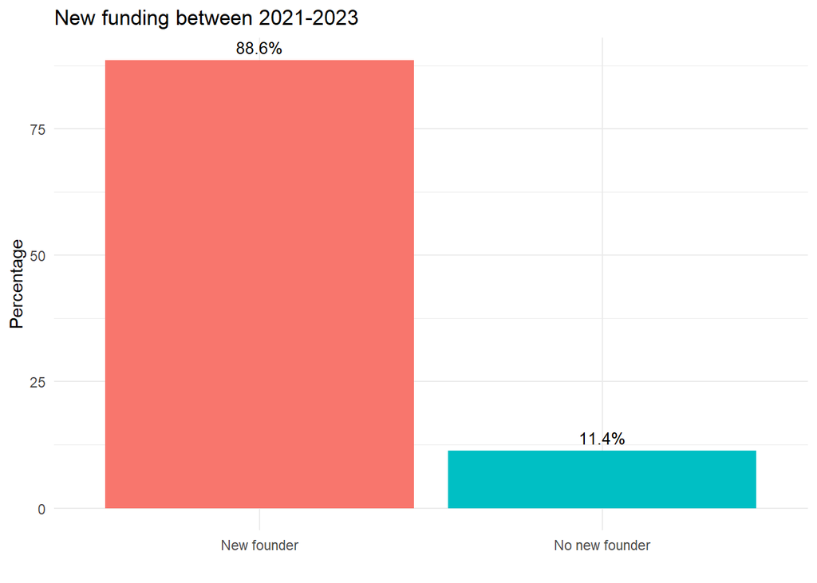

*Source of new funding*

| Source | Percentage |
| --- | --- |
| Feminist | 45.8 |
| INGOS | 31.0 |
| Philanthropic | 26.2 |
| Individual | 18.1 |
| Multilateral | 14.2 |
| Bilateral | 13.7 |
| Government | 12.2 |
| Private | 9.3 |
| Other | 3.8 |

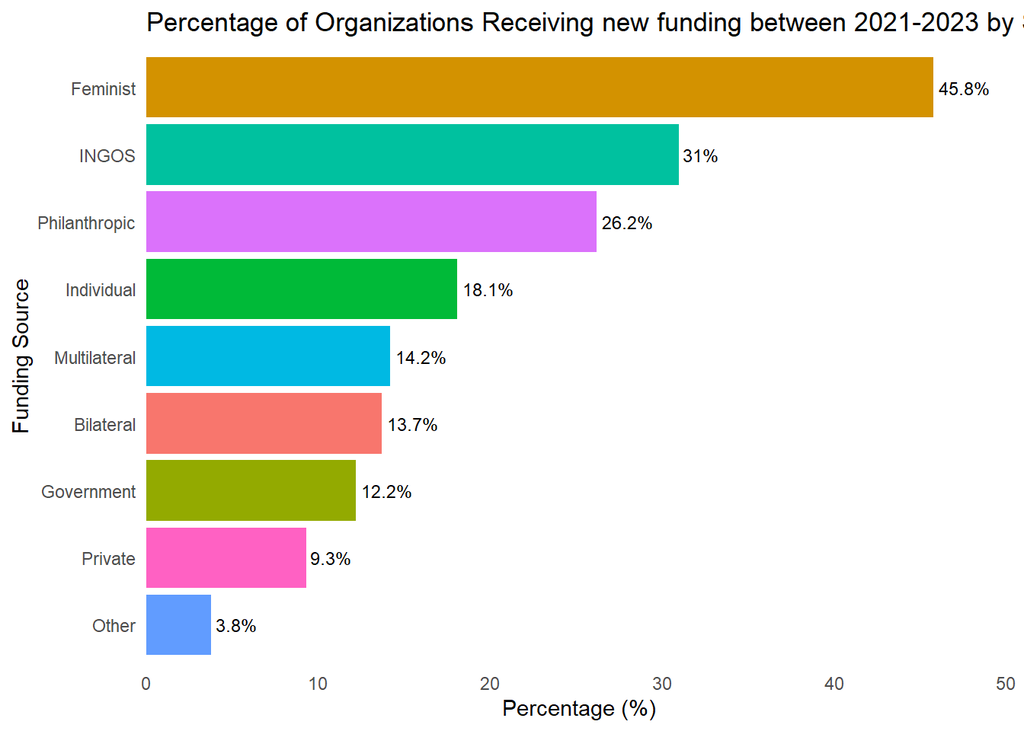

**Loss of funding**

Q19. Between 2021 and 2023, did your group, organization and/or movement lose funding from any long-term funders who previously supported your work?

[figure not shown]

*Organizations that Experienced a Decrease in Funding by Source Between 2021 and 2023*

| Source | Percentage |
| --- | --- |
| INGOS | 14.5 |
| Philanthropic | 12.6 |
| Private | 11.9 |
| Individual | 8.5 |
| Multilateral | 8.4 |
| Bilateral | 7.0 |
| Government | 5.5 |
| Feminist | 3.3 |
| Other | 2.3 |

[figure not shown]

**Loss of funding impact**

Q20. What impact has this loss of funding had on your group, organization and/or movement?

| Source | Percentage |
| --- | --- |
| Activity reduction | 59.9 |
| Staff faced a salary gap | 34.3 |
| Staff reduction | 32.4 |
| No big impact | 12.4 |
| Discontinuation of programs or projects | 12.4 |
| Other | 11.2 |

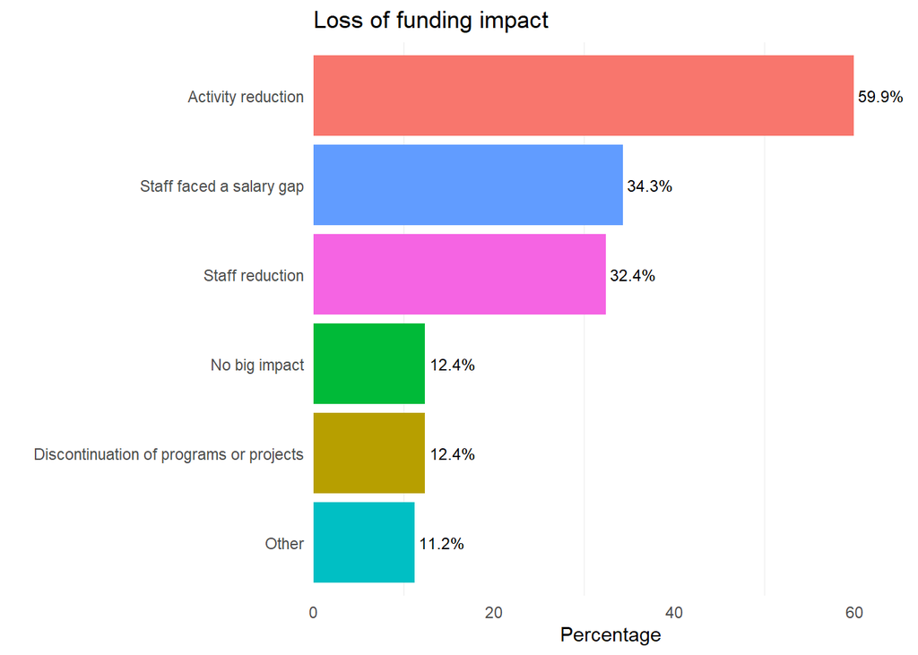

**-.-.-.-.-.-.-.-.-.-.-.-.-.-.-.-.-.-.-.-.-.-.-.-.-.-.-.-.-.-**

### Sub-section 2.2: Type of funding

**Core funding (or general operating support)**: unrestricted, flexible funding that can be used for all kinds of expenses, from overheads to programme costs.

**Project/programme/activity funding**: restricted funding that can only be used to cover the costs of a specific project or programme.

**Urgent response or emergency funding**: short-term funding that is moved quickly in response to urgent and often unpredicted crises, for example, armed conflict, natural disaster, security crisis, public health emergency and/ or in response to safety risk, mental health and care crisis among staff and/or movement partners.

**Percentage of external funding by type of funding**

Q21. For the years 2021, 2022 and 2023, indicate the percentage of each type of external funding that your group, organization and/or movement received

*2023*

| Percentage external funding | Core | Project | Emergency |
| --- | --- | --- | --- |
| 1 Up to 25% | 62.8 | 31.6 | 91.3 |
| 2 Between 26%-50% | 21.2 | 24.5 | 7.1 |
| 3 Between 51%-75% | 7.8 | 16.5 | 0.8 |
| 4 Over 75% | 8.2 | 27.5 | 0.8 |

*2022*

| Percentage external funding | Core | Project | Emergency |
| --- | --- | --- | --- |
| 1 Up to 25% | 67.2 | 34.3 | 91.8 |
| 2 Between 26%-50% | 19.0 | 23.9 | 6.5 |
| 3 Between 51%-75% | 6.6 | 14.3 | 0.7 |
| 4 Over 75% | 7.2 | 27.5 | 1.0 |

*2021*

| Percentage external funding | Core | Project | Emergency |
| --- | --- | --- | --- |
| 1 Up to 25% | 68.1 | 38.9 | 90.6 |
| 2 Between 26%-50% | 19.4 | 22.6 | 8.0 |
| 3 Between 51%-75% | 4.6 | 14.2 | 0.7 |
| 4 Over 75% | 7.9 | 24.3 | 0.7 |

**Grants average duration**

Q22. Between 2021 and 2023, what was the average duration of grants your group, organization and/or movement received?

[figure not shown]

**Context**

Q23. If you received urgent response or emergency funding between 2021 and 2023, what was the context you were responding to with these funds?

| Context | Percentage |
| --- | --- |
| Other | 12.3 |
| Holistic safety, protection or collective care | 1.8 |
| Digital security threats | 1.6 |
| Physical security threats | 1.3 |
| Crack-down on civic space and anti-rights backlash | 1.1 |
| Climate crisis-related disaster | 0.9 |
| Other health-related emergencies | 0.7 |
| COVID-19 pandemic | 0.4 |
| Outbreak of conflict, war and violence | 0.2 |

*Other responses*

| Specific context |
| --- |
| Abortion Fund |
| Advocacy Actions to End Sexual & Gender Based Violence in the Mano River Region |
| Advocacy and empowerment |
| Apoyar con anticoncepción y anticoncepción de emergencia; equipos y kits de bioseguridad para comadronas; alimentos para mujeres y jóvenes |
| Apoyo al proceso constituyente |
| Asistencia medica, psicológica, jurídica, y alimentación urgente para mujeres indígenas en situación de violencia extrema |
| Aumento da violencia de genero |
| Autonomía económica |
| Awareness and Organizing |
| Catastrophe naturelle (éruption volcanique) |
| Demanda de retirada de direitos das trabalhadoras domésticas no país. |
| Economic collapse in Lebanon |
| Forum Génération Egalité |
| GBV |
| GBV sheltering .counslling and medication |
| Huracán Otis en Guerrero, se realizaron brigadas de salud |
| Insecurité |
| Internal crisis |
| Invest.formação, autocuidado e segurança psicol. equipe de atend.PenhaS, suporte a mulheres vítimas de violência, aumento exponencial da demanda. |
| It was mental health and welbeing support related grant from Urgent Action Fund Asia & The Pacific. |
| Legal costs (diffamation) |
| Migration crisis |
| No |
| Não consigo inserir neste campo a resposta completa….. |
| OSF gave us an emergency grant in 2022 as they exited the country. |
| Pas de financement reçu |
| Personal |
| Promotion des droits des femmes et filles en situation de handicap |
| Rape and urgent intervention for rape survivors with disabilities. Acid attack on an adolescent girl whose mother has mobility challenges |
| Relocation support funds within PNG. |
| Response to prison jail officials and filing suit on behalf of members |
| Rise in anti lgbtiq+ campaigns. |
| SGBV |
| Social and financial education and sexual and reproductive health |
| Support for women’s human rights defenders. |
| UAF A&W Rapid Response Grant-Making Program SECURITY AND WELL-BEING GRANT |
| UN Convention Report Support |
| Violence Survivors |
| Widowhood rights |
| Women Human Rights Defenders, women’s rights |
| Women empowerment |
| Women protection |
| battering, rape, feminizid etc |
| crisis social, apoyo alimentario y problemáticas interseccionales de mujeres migrantes en cárcel |
| infrastructure development related displacement |
| insécurité alimentaire pendant la période de soudure |
| mariage forcés des jeunes filles |
| salud |
| sensibilisation sur le mariage des enfants |
| tremblement de terre Haouz |
| Éruption volcanique |

**-.-.-.-.-.-.-.-.-.-.-.-.-.-.-.-.-.-.-.-.-.-.-.-.-.-.-.-.-.-**

### Sub-section 2.3: Funding to counter anti-rights and anti-gender trends

Q25. Between 2021 and 2023, did you receive funding for work to counter the rising power of anti-rights actors and anti-gender trends?

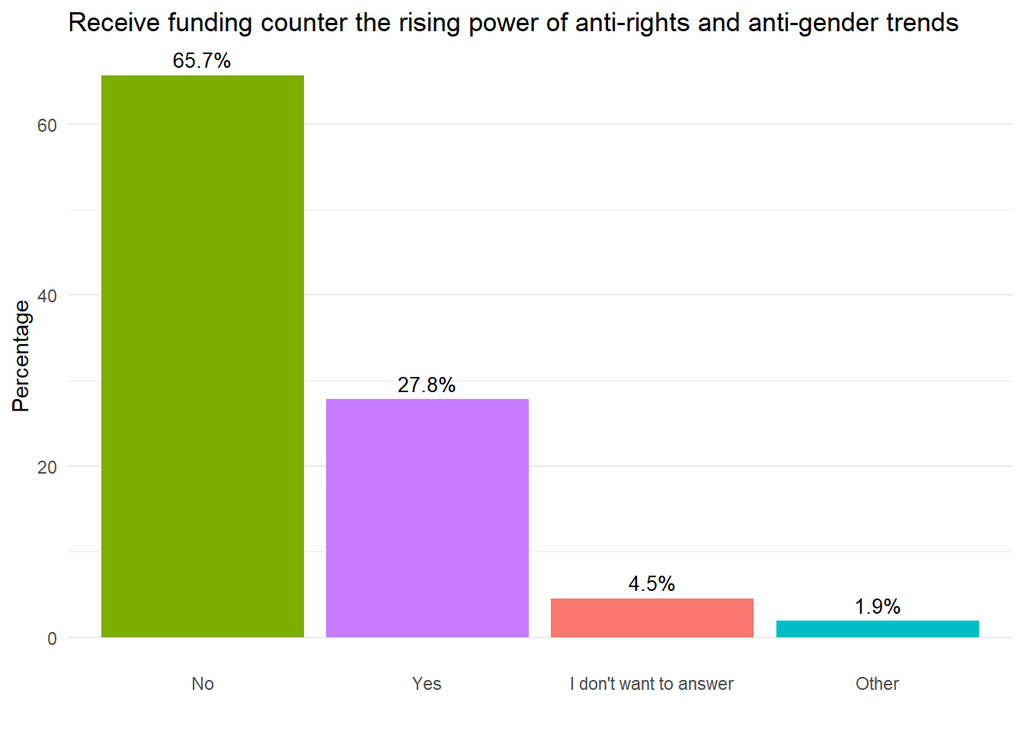

Q26. Did this funding come from a funder who had not supported your group, organization and/or movement before 2021? If yes, please select which type of funder

| Source | Percentage |
| --- | --- |
| No or not sure | 30.3 |
| Yes | 69.7 |

*Source counter anti-rights and anti-gender trends funding*

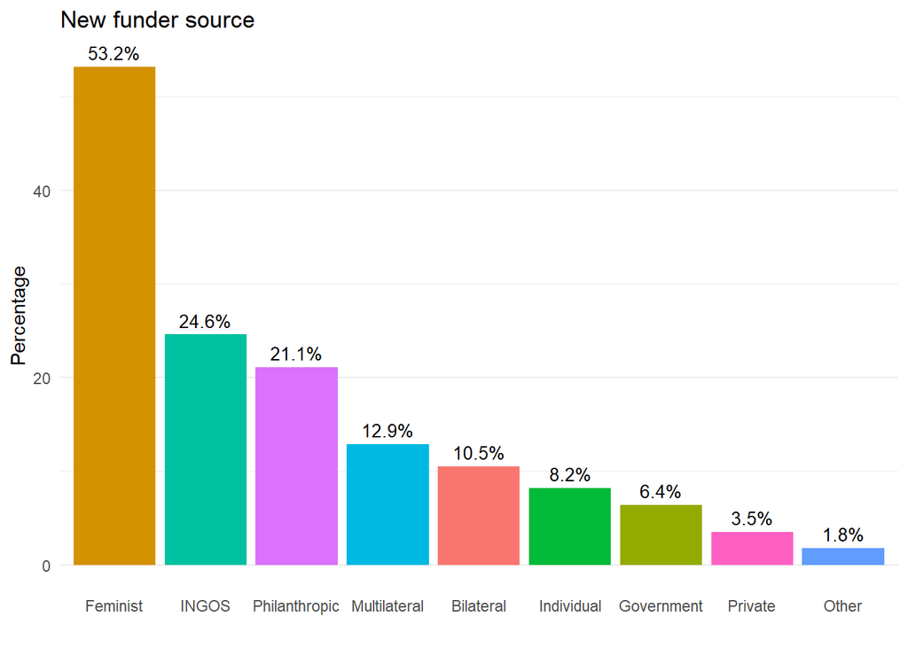

Q27. What kind of work did you undertake with this funding?

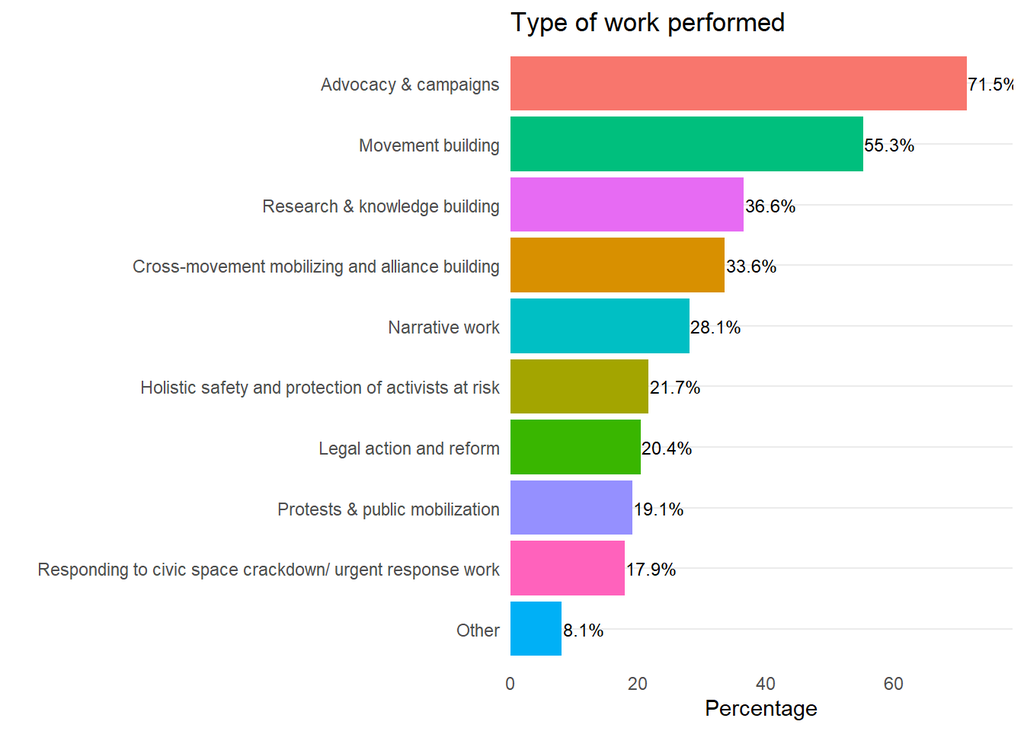

**-.-.-.-.-.-.-.-.-.-.-.-.-.-.-.-.-.-.-.-.-.-.-.-.-.-.-.-.-.-**

**Resources generated autonomously** are the financial, human or material resources that your group, organization and/or movement generates independent from external funders.

*To learn more about the power of autonomous self-generated resourcing, see:* [https://our-resource.com/about/] (https://our-resource.com/about/)

Q28. Between 2021 and 2023, did your group, organization and/or movement rely on any of the following forms of autonomous resourcing to generate income and fund your work?

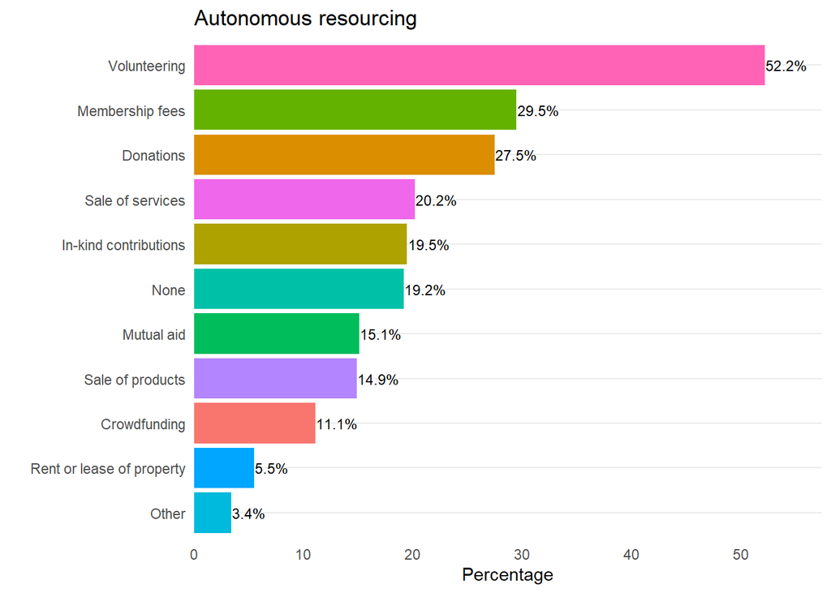

Q29. Between 2021 and 2023, how did your group, organization and/or movement’s reliance on autonomous resourcing change?

Change

Count

Percentage

1. Grew substantively

128

14.0

2. Grew slightly

300

32.8

3. Stayed the same

279

30.5

4. Decreased slightly

114

12.5

5. Decreased substantially

93

10.2

**-.-.-.-.-.-.-.-.-.-.-.-.-.-.-.-.-.-.-.-.-.-.-.-.-.-.-.-.-.-**

## Section 3: Shifting Power

Q30. Has your group, organization and/or movement ever had to shift its priorities, strategies or ways of working to be eligible for and/or increase the chances of receiving external funding?

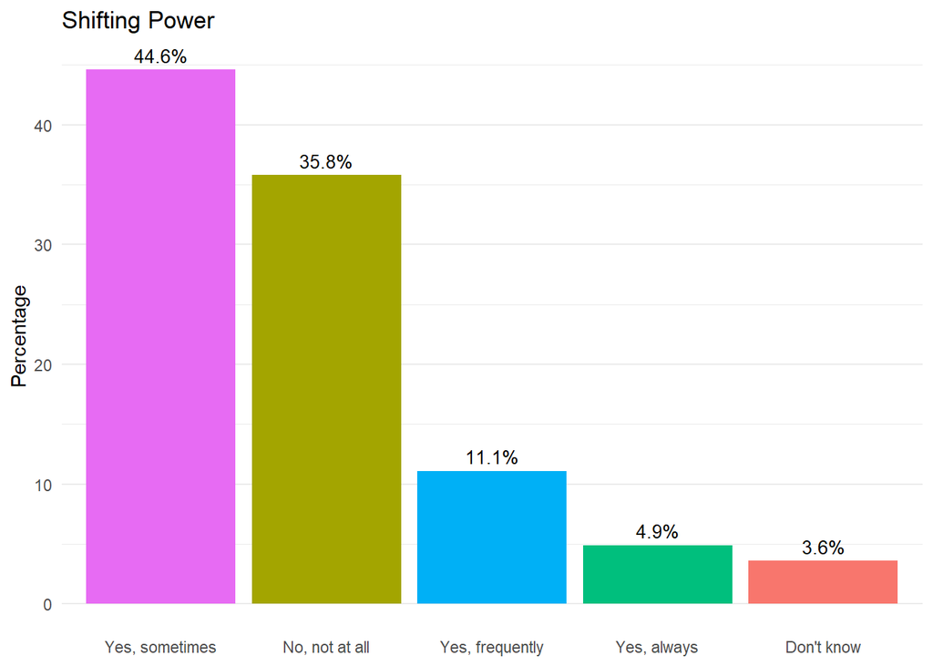

Q31. In your experience, what are some of the best practices funders have used to share their power with your group, organization, and/or movement?

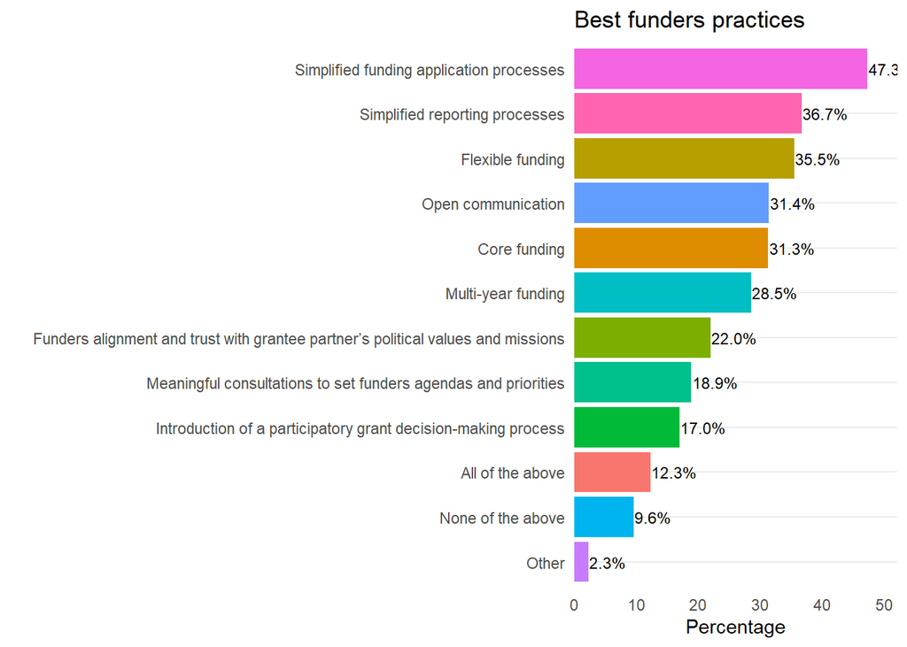

Q32. To what extent does your group, organization, and/or movement face the following barriers in accessing external funding?

| Response | No agreement | Somewhat agree | Strongly agree |
| --- | --- | --- | --- |
| We are skilled in resource mobilization and face relatively few difficulties to resource our work | 38.9 | 43.9 | 17.2 |
| We don’t have enough information on where, from whom and what funding is actually available | 18.7 | 41.6 | 39.6 |
| We don’t have the staff capacity and/or experience to apply for funding | 37.5 | 40.7 | 21.9 |
| Funding processes are complex, inaccessible and unrealistic | 14.8 | 46.2 | 39.0 |
| Monitoring and evaluation processes are extremely technical and far from the reality of feminist organizing | 20.3 | 43.7 | 36.0 |
| We often don’t meet funders’ legal, judicial and/or administrative requirements to be eligible for funding | 35.0 | 32.5 | 32.6 |
| We work in regions and/or on issues that are criminalized by our governments and face restrictions and/or threats to receiving foreign funding | 48.7 | 27.4 | 23.9 |
| We are under pressure to comply with funders political strategies, including not engaging with certain agendas and/or in certain regions | 42.4 | 37.5 | 20.1 |
| There is very little funding available for the movements, agendas and/ or countries & regions we work with | 13.8 | 35.8 | 50.3 |
| There is very little transparency about funders’ priorities, assessment criteria and who receives funding in the end | 24.2 | 41.0 | 34.8 |

Q33. How can AWID support you with these challenges?

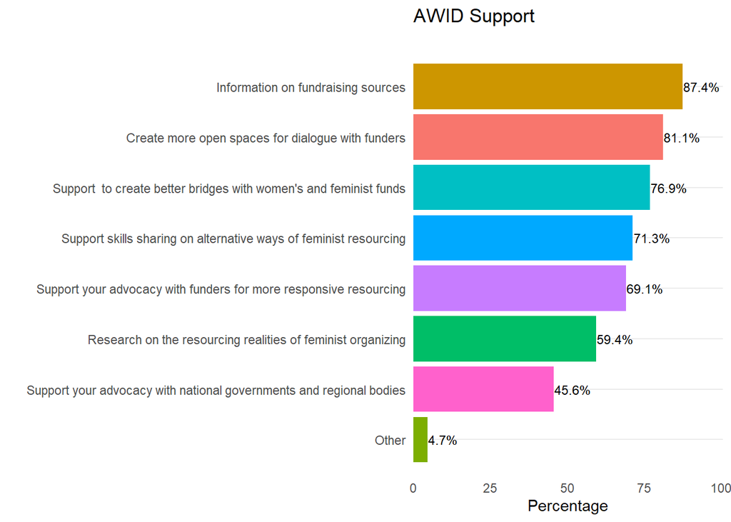

**-.-.-.-.-.-.-.-.-.-.-.-.-.-.-.-.-.-.-.-.-.-.-.-.-.-.-.-.-.-**

## Section 4: Sustainability

Q36. In percentage, how much of your group, organization and/or movement’s budget has been secured for the following years?

| Percentage of budget secured for the following years | 2025 | 2026 |
| --- | --- | --- |
| 0 Zero | 28.3 | 45.2 |
| 1 Lower than 30% | 27.8 | 22.7 |
| 2 Between 30% and 40% | 17.3 | 11.9 |
| 3 Between 50% and 60% | 14.3 | 9.6 |
| 4 Between 70% and 80% | 8.7 | 7.3 |
| 5 Higher than 80% | 3.7 | 3.2 |

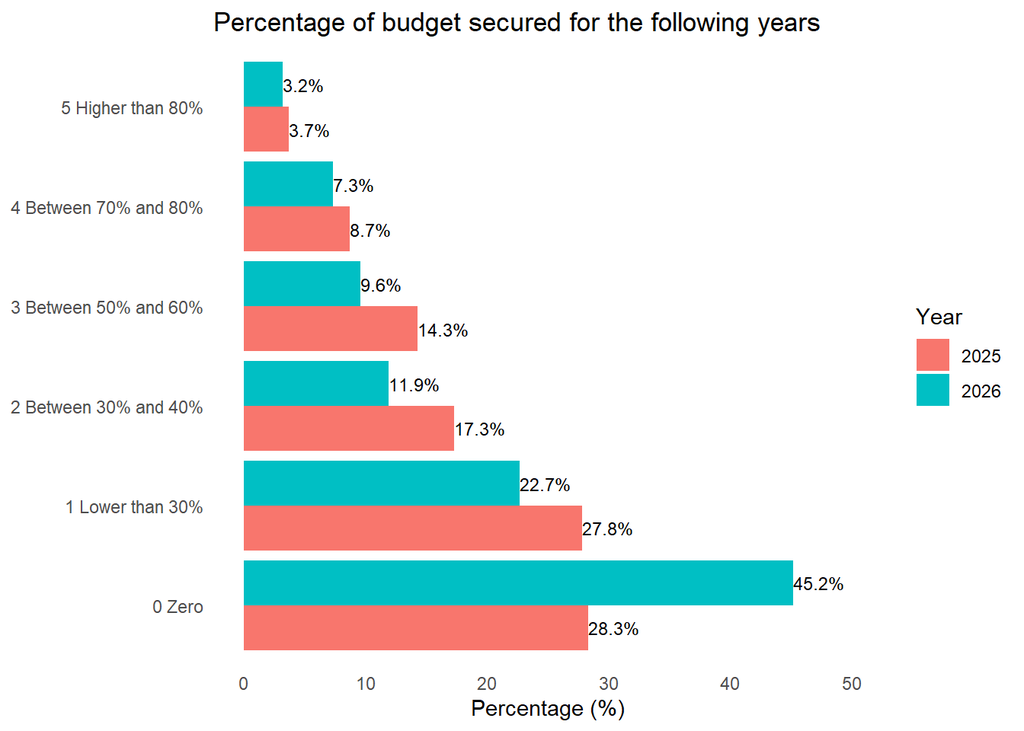

_____

*Q37. If your external funding were to end immediately, how many months could your group, organization and/or movement operate using only savings and reserves?

| Operate on savings | Total | Percentage |
| --- | --- | --- |
| Up to 3 months | 247 | 31.9 |
| 3-6 months | 245 | 31.7 |
| 6-12 months | 173 | 22.4 |
| 12-24 months | 63 | 8.1 |
| Over 24 months | 46 | 5.9 |

*Q38. Has your group, organization and/or movement ever been in jeopardy of closing due to insecure funding?

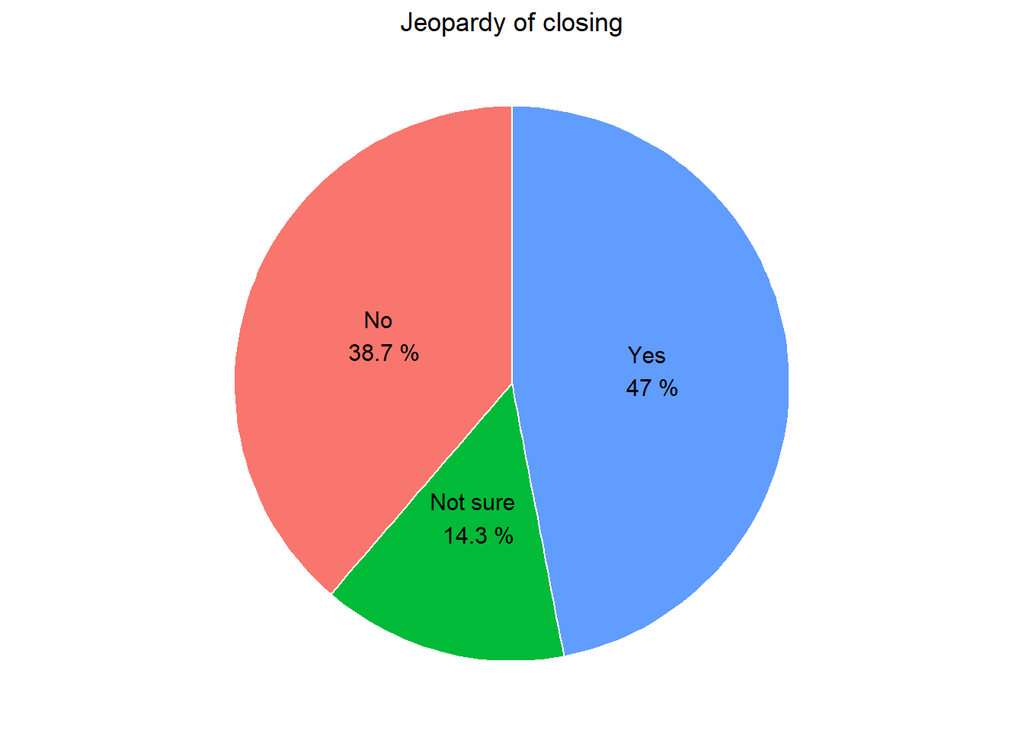

Q39. Is your group, organization and/or movement currently in a position to offer the following employment conditions and benefits to staff?

| Staff benefits | Percentage |
| --- | --- |
| No | 44.5 |
| Yes | 55.5 |

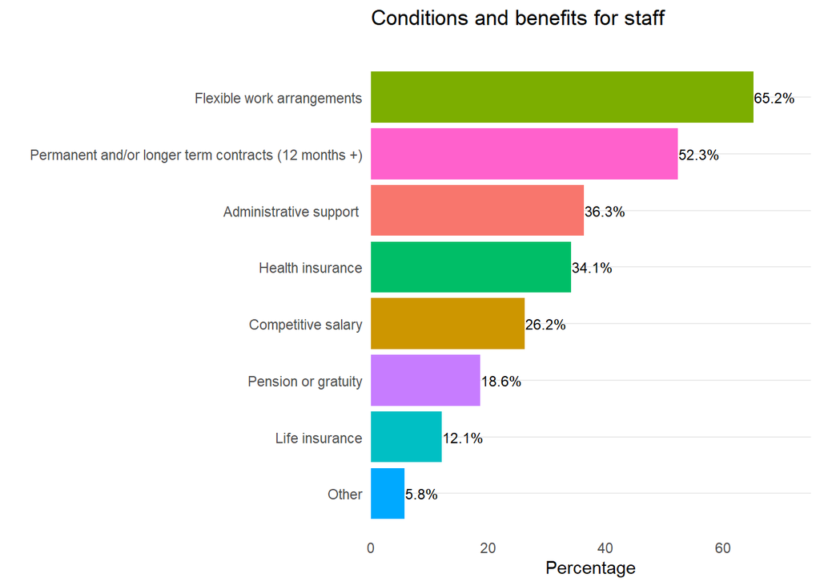

*Q40. Between 2021 and 2023, how many paid, full-time staff focusing primarily on resource mobilization have been employed by your group, organization and/or movement?

| Resource mobilization staff | Total | Percentage |
| --- | --- | --- |
| 1 person | 185 | 14.8 |
| 2-3 staff | 225 | 18.0 |
| 3-5 staff | 143 | 11.4 |
| All our staff | 95 | 7.6 |
| None, this work is voluntary | 541 | 43.3 |
| Other | 60 | 4.8 |

**-.-.-.-.-.-.-.-.-.-.-.-.-.-.-.-.-.-.-.-.-.-.-.-.-.-.-.-.-.-**

## Section 5: Key Aspirations

Q41. Between 2021 and 2023, was your group, organization and/or movement’s income sufficient to realize your strategic goals?

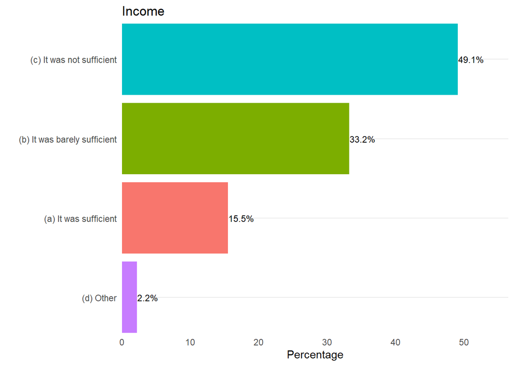

*Q42. How much would your aspirational budget be (in $USD amount)?

Aspirational budget

Total

Percentage

1. Zero budget

33

2.6

2. <5,000 USD

54

4.3

3. 5,001-10,000 USD

88

7.0

4. 10,001-30,000 USD

134

10.7

5. 30,001 -50,000 USD

156

12.5

6. 50,001 - 100,000 USD

184

14.7

7. 100,001 - 500,000 USD

345

27.6

8. 500,001 - 1,000,000 USD

126

10.1

1. 1,000,001 + USD

129

10.3

**-.-.-.-.-.-.-.-.-.-.-.-.-.-.-.-.-.-.-.-.-.-.-.-.-.-.-.-.-.-**

## Section 6: Next Steps

*Q45. Did anyone from your group, organization and/or movement respond to AWID’s Where is the Money survey in 2008 or 2011?

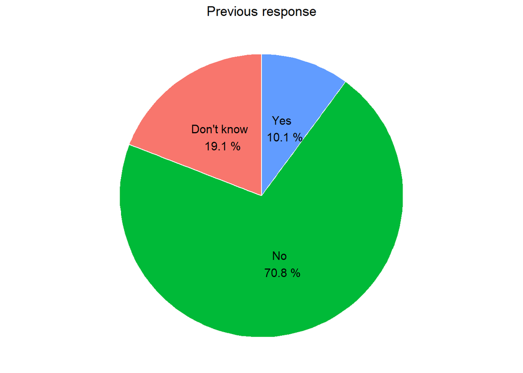

_____

Q46. In which language did you answer the survey?

| Language | Total | Percentage |
| --- | --- | --- |
| English | 610 | 56.6 |
| Spanish | 216 | 20.1 |
| French | 159 | 14.8 |
| Portuguese | 49 | 4.5 |
| Arabic | 37 | 3.4 |
| Russian | 6 | 0.6 |

*Q47. Would you be open to AWID contacting you about next steps in the WITM research, including the interview?

| Open to be contacted | Total | Percentage |
| --- | --- | --- |
| Yes | 1129 | 91.6 |
| No | 33 | 2.7 |
| Don’t know | 70 | 5.7 |